# NOAA Storm event analysis

KHYS / kshu

3 Apr 2018

# Synopsis

The U.S. National Climatic Data Center (NCDC), a weather data archive under the National Oceanic and Atmospheric Administration, maintains a database of severe weather events. It includes timing and estimates of location, fatalities, injuries, property and crop damage as well encodings for event type (“`EVTYPE`”“) and prepared remarks. The overwhelming majority of the work supporting this”report" was to clean the myriad `EVTYPE` variable, numbering nearly 900 types, into the several dozen types at the [NCDC Storm Events database](https://www.ncdc.noaa.gov/stormevents/). Despite the clear imperfections resulting from this cleaning, the results inferred from the `ggplot2`-produced plots were not surprising: tornadoes, flooding, hurricanes/typhoons, and heat waves were among the most consequential events to public health and finances.

# Processing

First, the relevant libraries are loaded and then the `.csv.bz2` file downloaded and read into a `tibble`.

```r
urlData<-paste("https://d396qusza40orc.cloudfront.net/repdata%2Fdata",
               "%2FStormData.csv.bz2",sep="")
# download.file(urlData, "StormData.csv.bz2")
## Calling unzip will produce an error
stormData<-tbl_df(read.csv("StormData.csv.bz2"))
```

In order to answer the question on economic damages, the decoding of the variable `PROPDMGEXP` is necessary.

```r
stormData<-stormData %>%
  mutate(BGN_DATE=as.Date(BGN_DATE, "%m/%d/%Y"),
         REMARKS=as.character(REMARKS)) %>%
  rename(FujitaRating=F)
levels(stormData$PROPDMGEXP)
```

```
##  [1] ""  "-" "?" "+" "0" "1" "2" "3" "4" "5" "6" "7" "8" "B" "h" "H" "K"
## [18] "m" "M"
```

```r
dashExp<-stormData %>% filter(PROPDMGEXP=="-")
qExp<-stormData %>% filter(PROPDMGEXP=="?")
plusExp<-stormData %>% filter(PROPDMGEXP=="+")
digitExp<-stormData %>%
  filter(PROPDMG != 0 & PROPDMGEXP %in% as.character(seq(0,8)))

parkColoradoHail<-stormData %>%
  filter(PROPDMG != 0 & PROPDMGEXP == as.character(0) &
           BGN_DATE==as.Date("1994-08-04") &
           STATE=="CO" & COUNTYNAME=="PARK" & EVTYPE=="HAIL")
toMultiplier<-function(x) {
  return(case_when(x %in% c("","-","?") ~ 0,
                   x == "+" ~ 1,
                   x %in% as.character(seq(0,8)) ~ 10,
                   toupper(x) == "H" ~ 100,
                   toupper(x) == "K" ~ 1E3,
                   toupper(x) == "M" ~ 1E6,
                   toupper(x) == "B" ~ 1E9,
                   TRUE ~ as.numeric(NA)))
}
# stormData<-stormData %>% select(-(MultPropDmg:typeEvent))
stormData<-stormData %>%
  mutate(MultPropDmg=toMultiplier(PROPDMGEXP),
         MultCropDmg=toMultiplier(CROPDMGEXP)) %>%
  mutate(ActualPropDmg=MultPropDmg * PROPDMG,
         ActualCropDmg=MultCropDmg * CROPDMG) %>%
  mutate(TotalDmg=ActualPropDmg+ActualCropDmg)
```

As an example, a hail event in Park County, Colorado on 1994-08-04 is listed with a `PROPDMG` of 4 and `PROPDMGEXP` of 0. Searching at the [NCDC Storm Events database](https://www.ncdc.noaa.gov/stormevents/) results in property damages of 0.04K. Thus, if `PROPDMGEXP = 0`, it is actually a multiplier of 10.

Now comes the renaming of the `EVTYPE` variable; first, some analysis was performed on the `FujitaRating` variable to determine whether the simple existence of a Fujita rating is sufficient to label an event a Tornado.

```r
stormData<-stormData %>%
  # remove excess white space and convert all EVTYPE to uppercase
  mutate(EVTYPE=toupper(trimws(as.character(EVTYPE)))) %>%
  mutate(EVTYPE=gsub("/ ","", EVTYPE)) %>%
  mutate(FujitaRating=ifelse(grepl("F[0-5]", EVTYPE),
                             as.integer(str_extract(EVTYPE,"[0-5]")),
                             FujitaRating))
unique(unlist(stormData %>%
                filter(!is.na(FujitaRating)) %>%
                select(EVTYPE)))
```

```
##  [1] "TORNADO"            "TORNADO F0"         "TORNADOS"
##  [4] "WATERSPOUT/TORNADO" "TORNADO F3"         "TORNADO F1"
##  [7] "TORNADO/WATERSPOUT" "TORNADO F2"         "TORNADOES"
## [10] "HEAVY RAIN"         "FUNNEL CLOUD"       "TSTM WIND"
```

```r
nonTornadicFujitas<-stormData %>%
  filter(!is.na(FujitaRating) & EVTYPE %in% c("HEAVY RAIN","TSTM WIND"))
table(nonTornadicFujitas$EVTYPE)
```

```
##
## HEAVY RAIN  TSTM WIND
##          1          3
```

```r
wordTstm<-"THU|TSTM"
tStmRegex<-paste("^(",
                 wordTstm,
                 "|(SEV(.)+(",
                 wordTstm,
                 "))|(GU(.)+(",
                 wordTstm,
                 ")))",
                 sep=""
)
nominalTstm<-stormData %>% filter(grepl(tStmRegex,EVTYPE))

stormData<-stormData %>% mutate(typeEvent=ifelse(!is.na(FujitaRating),
                                                 "Tornado",
                                                 as.character(NA)))
```

Examining the event types with a name other than “Tornado” or “Funnel cloud”, there are only 4 such entries in the data frame. As these comprise 0 fatalities and injuries, and 2.1210^{5} in damage, accounting for 0.0017317% of the nominal thunderstorm damage, I conclude that mere presence of a Fujita rating is sufficient to label an event tornadic. Note that `WATERSPOUT/TORNADO` was included as some (land) tornadoes *do* begin their lives as waterspouts.

Now the examination of the cases where `EVTYPE` has some form of “tornado” in the name. Again, `WATERSPOUT/TORNADO` and its variants will be treated as tornadic, not waterspouts.

```r
nonFujitaTorn<-stormData %>%
  filter(is.na(FujitaRating) & grepl("TORN", EVTYPE))
unique(nonFujitaTorn$EVTYPE)
```

```
## [1] "TORNADO"                    "WATERSPOUT/TORNADO"
## [3] "WATERSPOUT TORNADO"         "WATERSPOUT-TORNADO"
## [5] "TORNADOES, TSTM WIND, HAIL" "COLD AIR TORNADO"
## [7] "WATERSPOUTTORNADO"          "TORNDAO"
## [9] "TORNADO DEBRIS"
```

```r
centuryStorm<-stormData %>% filter(grepl("TORN(.)+TSTM", EVTYPE))
csType<-unlist(centuryStorm$EVTYPE)
```

The “odd one out” `EVTYPE` here is TORNADOES, TSTM WIND, HAIL, and this `EVTYPE` happens to correspond with the 1993 Storm of the Century, which began in the state of Florida on 1993-03-12. The NCDC remarks for this event are as follows:

```r
print(unlist(centuryStorm$REMARKS))
```

```
## [1] "Tornadoes, Thunderstorm Winds, Hail, Storm Surge, Flooding, Beach Erosion, Snow\n\nThe \"Storm Of The Century\" roared across Florida producing a variety of severe and unusual weather conditions for a period of about 18 hours from late Friday the 12th through late afternoon Saturday the 13th…
```

Reading the remarks, the NCDC characterizes the event in Florida as beginning with a “severe squall line”, which is by definition a line of thunderstorms. The narrative also notes multiple tornadoes and the rare (for Florida) winter storm surge, which are also valid event types. However, for the purpose of simplifying this analysis, the “cleaned” `EVTYPE`, stored in `typeEvent`, will be “Thunderstorm Wind”. The `typeEvent` is now renamed accordingly:

```r
idxCentury<-which(stormData$EVTYPE==csType)
idxNonFujita<-setdiff(which(is.na(stormData$FujitaRating) &
                              grepl("TORN", stormData$EVTYPE)),
                      idxCentury)
stormData$typeEvent[idxNonFujita]<-"Tornado"
stormData$typeEvent[idxCentury]<-"Thunderstorm Wind"
```

Before proceeding to other values of `EVTYPE`, 6.7% of the observations now have a cleaned `typeEvent` value. The code uses `case_when()`, similar to a `switch` and `case` clause series in Java.

- Flash floods processed; the reader is invited to parse this Regex for themselves.
- Non-flash floods (output of `typeEvent="Flood"`) occur when there is no flash element or any coastal flooding or beach erosion.
- The choice to classify `EVTYPE` values containing `"COAST"`, `"BEACH"`, and/or `"EROSION"`, but not the word `"SURGE"` as being `typeEvent="Coastal Flood"` was somewhat arbitrary, as coastal flooding and beach erosion can clearly occur with Storm Surge.
- For `typeEvent="Thunderstorm Wind"`, the regular expression `tStmRegex` was chosen so that event descriptions beginning with `SEVERE THUNDERSTORM`, `MARINE THUNDERSTORM`, `THUNDERSTORM`, or `TSTORM` would take precedent, regardless of the presence of other possible events afterwards, such as `EVTYPE="TSTM WIND/HAIL"`. This guideline will be observed henceforth unless otherwise stated.
- Events containing `WATERSP` but not the `TORN` prefix are classified as `typeEvent=Waterspout`.

```r
tStmRegex
```

```
## [1] "^(THU|TSTM|(SEV(.)+(THU|TSTM))|(GU(.)+(THU|TSTM)))"
```

```r
stormData<-stormData %>%
  mutate(typeEvent=ifelse(!is.na(typeEvent),
                          typeEvent,
                          case_when(
                            grepl("(^FLASH)|(FLOOD(.){1}FLASH)",EVTYPE) |
                              grepl("( FLASH FLOOD)$",EVTYPE) ~
                              "Flash Flood",
                            grepl("FLOOD|FLD",EVTYPE) &
                              !grepl("(FLASH|COAST|BEACH|EROSION|THU)",
                                     EVTYPE) ~
                              "Flood",
                            grepl("(COAST|BEACH|EROSION)",EVTYPE) &
                              !grepl("SURGE",EVTYPE) ~
                              "Coastal Flood",
                            grepl("SURGE",EVTYPE) ~
                              "Storm Surge/Tide",
                            grepl(tStmRegex,EVTYPE) ~
                              "Thunderstorm Wind",
                            grepl(paste("^(MAR(.)+(",
                                        wordTstm,
                                        "))",
                                        sep=""),EVTYPE) ~
                              "Marine Thunderstorm Wind",
                            grepl("HUR|TYP",EVTYPE) ~
                              "Hurricane (Typhoon)",
                            grepl("TROP",EVTYPE) ~
                              "Tropical Storm or Depression",
                            grepl("(?=.*\\bWATERSP)(?!.*TORN)",
                                  EVTYPE,
                                  perl=TRUE) ~
                              "Waterspout",
                            TRUE ~ as.character(NA)
                          )
  )
  )
```

With 10 event types classified, there are now 54.2% of the observations with a cleaned `typeEvent` value.

```r
stormData<-stormData %>%
  mutate(typeEvent=ifelse(!is.na(typeEvent),
                          typeEvent,
                          case_when(
                            grepl("(^HAIL)|( HAIL$)",EVTYPE) &
                              !grepl("MAR",EVTYPE) ~
                              "Hail",
                            grepl("^((GU|HI|STRO)(.)+WIND)",EVTYPE) ~
                              "High or Strong Wind",
                            grepl("^(MAR(.)+WIND)",EVTYPE)~
                              "Marine High or Strong Wind",
                            grepl("^AST(.)+LO",EVTYPE)~
                              "Astronomical Low Tide",
                            grepl("^AVA",EVTYPE)~
                              "Avalanche",
                            grepl("^BLI",EVTYPE)~
                              "Blizzard",
                            grepl("LAK(.)+SN",EVTYPE)~
                              "Lake-Effect Snow",
                            grepl("^HEA(.)+SN",EVTYPE) &
                              !grepl("LAK",EVTYPE)~
                              "Heavy Snow",
                            grepl("FROST|FREEZE",EVTYPE) ~
                              "Frost/Freeze",
                            TRUE ~ as.character(NA)
                          )
  ))
stormData<-stormData %>%
  mutate(typeEvent=ifelse(!is.na(typeEvent),
                          typeEvent,
                          case_when(
                            grepl("(^COLD)|( COLD$)|(WIND(.)?CHILL)",EVTYPE) &
                              !grepl("AIR",EVTYPE)~
                              "Extreme Cold/Wind Chill",
                            grepl("(^([^/]*HEAT))|(REC(.)+HEAT)",EVTYPE)~
                              "Excessive Heat",
                            grepl("WIL",EVTYPE)~
                              "Wildfire",
                            grepl("^DROU",EVTYPE)~
                              "Drought",
                            grepl("(^DUST)|(DUST$)",EVTYPE)~
                              "Dust Devil or Storm",
                            grepl("^HEAVY RA",EVTYPE)~
                              "Heavy Rain",
                            grepl("^LIGHTN",EVTYPE)~
                              "Lightning",
                            grepl("VOL",EVTYPE)~
                              "Volcanic Ash",
                            grepl("WIL",EVTYPE)~
                              "Volcanic Ash",
                            grepl("WINT(.)+(MIX|WEA)",EVTYPE)~
                              "Other Wintry Weather",
                            grepl("^WINT(.)+ST",EVTYPE)~
                              "Winter Storm",
                            grepl("FUN",EVTYPE)~
                              "Funnel Cloud",
                            grepl("TSU",EVTYPE)~
                              "Tsunami",
                            grepl("RIP|SURF",EVTYPE)~
                              "Rip Current",
                            TRUE ~ as.character(NA)
                          )
  ))
stormData<-stormData %>%
  mutate(typeEvent=ifelse(!is.na(typeEvent),
                          typeEvent,
                          case_when(grepl("(FR(.)+RAIN)|SLE|(ICE ST)",
                                          EVTYPE)~
                                      "Ice Storm or Sleet",
                                    grepl("FR(.)+ING",EVTYPE) &
                                      !grepl("(RAIN)|(FOG)",EVTYPE)~
                                      "Other Wintry Weather",
                                    grepl("FOG",EVTYPE)~
                                      "Dense Fog",
                                    grepl("SMO",EVTYPE)~
                                      "Dense Smoke",
                                    TRUE ~ as.character(NA)
                          )))
```

With most (but not all) of the event types processed (35 of them), accounting for 99.5% of the observations, it is time to examine the entries with an empty `typeEvent`. One possible cutoff is entries with damage attaining 1 million dollars:

```r
missingMil<-stormData %>%
  filter(is.na(typeEvent) & TotalDmg>=1E6) %>%
  arrange(desc(TotalDmg))
table(missingMil$EVTYPE)
```

```
##
## ASTRONOMICAL HIGH TIDE           COOL AND WET              DAM BREAK
##                      3                      1                      1
##         DRY MICROBURST      EXCESSIVE WETNESS           FOREST FIRES
##                      1                      1                      1
##                    ICE           ICE AND SNOW       ICE/STRONG WINDS
##                      1                      1                      1
##              LANDSLIDE               MUDSLIDE                   RAIN
##                     34                      1                      1
##                   SNOW        UNSEASONAL RAIN                   WIND
##                      3                      2                      2
##          WIND AND WAVE
##                      1
```

Clearly, landslides account for the great majority of the unprocessed million-dollar events. Since they can be caused by a multitude of factors beyond weather, including earthquakes, volcanic eruptions, or even deliberate activity, they should be excluded. It remains to be demonstrated the approximate proportion of damages and casualties that is “missing” with the incomplete classification:

```r
trimmedStorm<-stormData %>% filter(EVTYPE != "LANDSLIDE")
dmgMissing<-unlist(trimmedStorm %>%
                     filter(is.na(typeEvent)) %>%
                     summarise(Dmg=sum(TotalDmg)))
dmgNonMissing<-unlist(trimmedStorm %>%
                        filter(!is.na(typeEvent)) %>%
                        summarise(Dmg=sum(TotalDmg)))
injMissing<-unlist(trimmedStorm %>%
                     filter(is.na(typeEvent)) %>%
                     summarise(Dmg=sum(INJURIES)))
injNonMissing<-unlist(trimmedStorm %>%
                        filter(!is.na(typeEvent)) %>%
                        summarise(Dmg=sum(INJURIES)))
fatMissing<-unlist(trimmedStorm %>%
                     filter(is.na(typeEvent)) %>%
                     summarise(Dmg=sum(FATALITIES)))
fatNonMissing<-unlist(trimmedStorm %>%
                        filter(!is.na(typeEvent)) %>%
                        summarise(Dmg=sum(FATALITIES)))
```

After removing landslide events, 0.05%, 1.11%, and 0.54% of the total damage (property and crop summed), fatalities, and injuries, respectively, have an unlabelled event type.

# Results

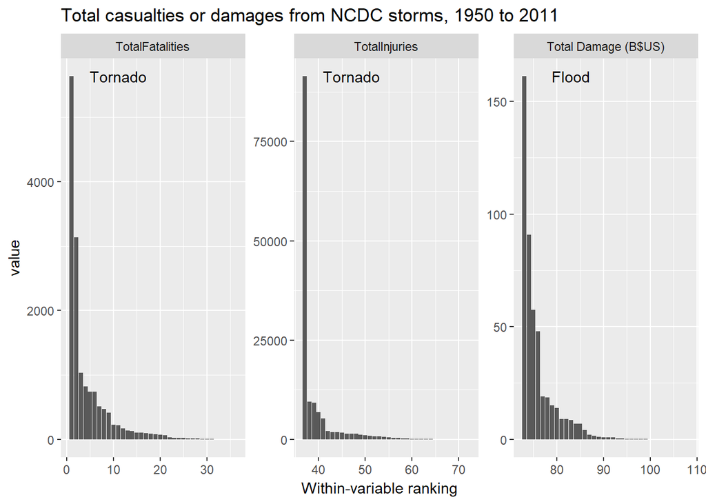

```r
trimmedStorm<-trimmedStorm %>%
  mutate(typeEvent=as.factor(ifelse(is.na(typeEvent),
                                    "UNCLASSIFIED",
                                    typeEvent)))
aggregates<-trimmedStorm %>%
  group_by(typeEvent) %>%
  dplyr::summarise(TotalFatalities=sum(FATALITIES),
                   TotalInjuries=sum(INJURIES),
                   TotalDamage=sum(TotalDmg) / 1E9)
names(aggregates)[ncol(aggregates)]<-"Total Damage (B$US)"

meltAgg<-melt(aggregates, id.vars="typeEvent")
meltAgg<-meltAgg %>%
  arrange(variable, desc(value)) %>%
  mutate(order=row_number())
worstEventsAgg<-meltAgg %>%
  group_by(variable) %>%
  dplyr::summarise(worstEvent=first(typeEvent),
                   order=first(order),
                   val=first(value))
barLabels<-worstEventsAgg

ggplot(data=meltAgg, aes(order, value)) +
  geom_bar(stat="identity") +
  facet_wrap(~variable, scales="free") +
  geom_text(data=barLabels,
            mapping=aes(x=order+10, y=val, label=worstEvent)) +
  labs(x="Within-variable ranking",
       title="Total casualties or damages from NCDC storms, 1950 to 2011")
```

Using `ggplot2`, and computing a summed aggregate over the entirety of 1950–2011, the worst event type by both total Fatalities and total Injuries was “Tornado”, with 5636 deaths and 91407 injuries. The worst event type by Total Damages (property and crop) was “Flood”, incurring a total of $161.09 billion.

```r
cumulatives<-apply(aggregates %>% select(-typeEvent),
                   MARGIN=2,
                   function(x) cumsum(rev(sort(x))) / sum(x))
cumulatives<-as.data.frame(cumulatives)
idx80<-apply(cumulatives, MARGIN=2, function(x) min(which(x >= 0.80)))
numTypes<-max(idx80)
apply(cumulatives, MARGIN=2, function(x) x[numTypes])
```

```
##     TotalFatalities       TotalInjuries Total Damage (B$US)
##            0.800887            0.884571            0.829267
```

Thus `numTypes` rows account for the above proportion of each variable.

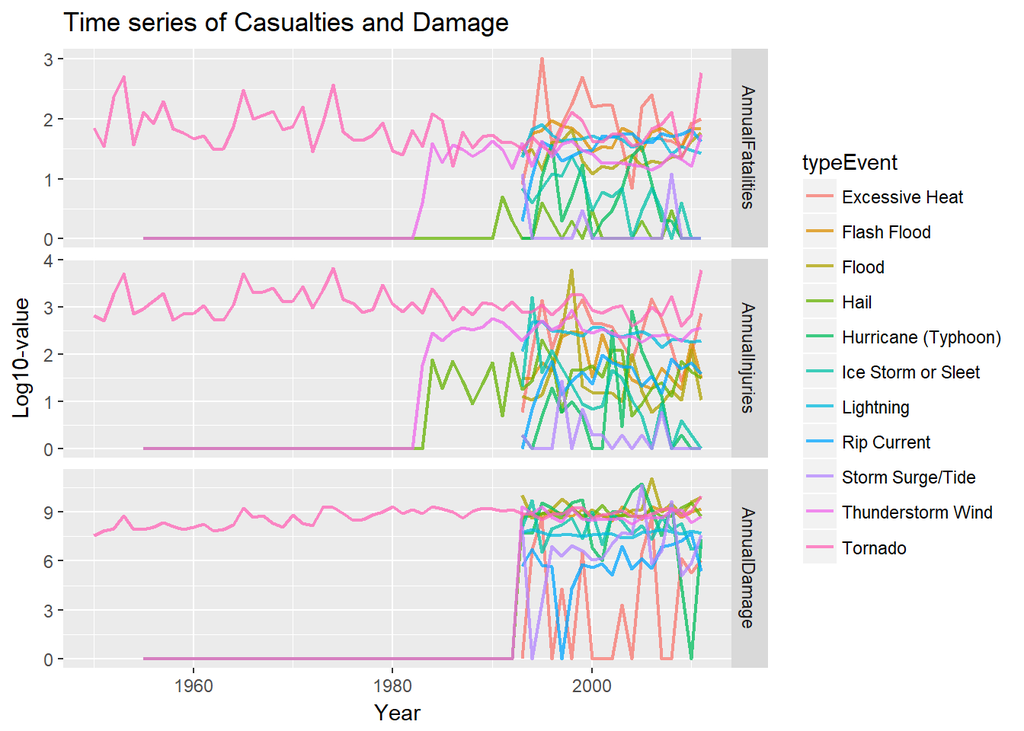

```r
aggregates<-as.data.frame(aggregates)
topTypes<-sapply(seq(2,ncol(aggregates)),
                 function(k) aggregates$typeEvent[
                   rev(order(aggregates[,k]))[seq(numTypes)]
                   ])
topTypes<-data.frame(topTypes)
names(topTypes)<-names(cumulatives)
tsStormTopOnly<-trimmedStorm %>%
  filter(typeEvent %in% unique(unlist(topTypes))) %>%
  mutate(yr=year(BGN_DATE)) %>%
  group_by(yr, typeEvent) %>%
  dplyr::summarise(AnnualFatalities=log10(1+sum(FATALITIES)),
                   AnnualInjuries=log10(1+sum(INJURIES)),
                   AnnualDamage=log10(1+sum(TotalDmg)))
meltedTS<-melt(tsStormTopOnly, id.vars=c("yr","typeEvent"))

ggplot(data=meltedTS, aes(x=yr, y=value,
                          color=typeEvent,
                          group=typeEvent)) +
  geom_line(size=0.75, alpha=0.75) +
  facet_grid(variable~., scales="free") +
  labs(x="Year", y="Log10-value",
       title="Time series of Casualties and Damage")
```